# Lab: Creating Animated Graphics

Xuemao Zhang

June 26, 2019

## Introduction

- In this session, we use two examples to show how to make animated graphics using the package `magick`.
- Install the following packages if you don’t have them.

```
                install.packages('datasauRus');
                install.packages('dplyr');
                install.packages('ggplot2');
                install.packages('magick');
```

## Datasaurus Data Visualization

### Datasaurus Data

- The [Datasaurus dataset](https://www.autodeskresearch.com/publications/samestats) urges people to “never trust summary statistics alone; always visualize your data”, since, while the data exhibits normal seeming statistics, plotting the data reveals a picture of a dinosaur.
- The R package [datasauRus](https://cran.r-project.org/web/packages/datasauRus/vignettes/Datasaurus.html) contains 13 sets of x-y data. Each sub-dataset has five statistics that are (almost) the same in each case. (These are the mean of x, mean of y, standard deviation of x, standard deviation of y, and Pearson correlation between x and y). However, scatter plots reveal that each sub-dataset looks very different.
- The datasets are intended to be used to teach students that it is important to plot their datasets, rather than relying only on statistics.

```r
library(datasauRus); library(dplyr); library(ggplot2);
str(datasaurus_dozen);
```

```
## Classes 'tbl_df', 'tbl' and 'data.frame':    1846 obs. of  3 variables:
##  $ dataset: chr  "dino" "dino" "dino" "dino" ...
##  $ x      : num  55.4 51.5 46.2 42.8 40.8 ...
##  $ y      : num  97.2 96 94.5 91.4 88.3 ...
##  - attr(*, "spec")=List of 2
##   ..$ cols   :List of 3
##   .. ..$ dataset: list()
##   .. .. ..- attr(*, "class")= chr  "collector_character" "collector"
##   .. ..$ x      : list()
##   .. .. ..- attr(*, "class")= chr  "collector_double" "collector"
##   .. ..$ y      : list()
##   .. .. ..- attr(*, "class")= chr  "collector_double" "collector"
##   ..$ default: list()
##   .. ..- attr(*, "class")= chr  "collector_guess" "collector"
##   ..- attr(*, "class")= chr "col_spec"
```

```r
dinosaur=filter(datasaurus_dozen, dataset=="dino");
attach(dinosaur);
c(mean(x), sd(x));
```

```
## [1] 54.26327 16.76514
```

```r
c(mean(y), sd(y));
```

```
## [1] 47.83225 26.93540
```

```r
cor(x,y);
```

```
## [1] -0.06447185
```

```r
detach(dinosaur);
```

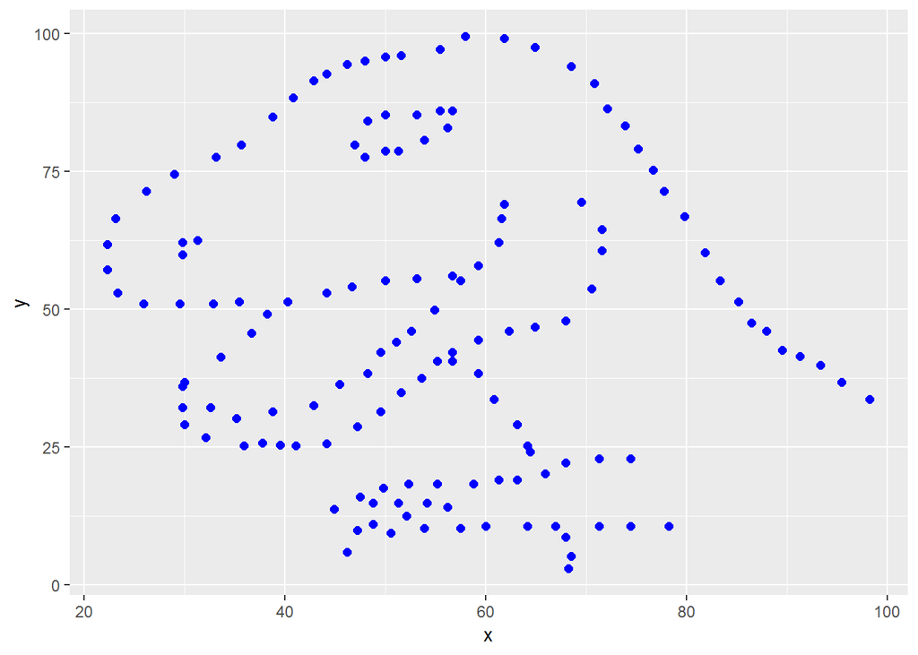

```r
ggplot(dinosaur, aes(x=x, y=y))+
  geom_point(col="blue",size=2);
```

### Plot of 13 data sets

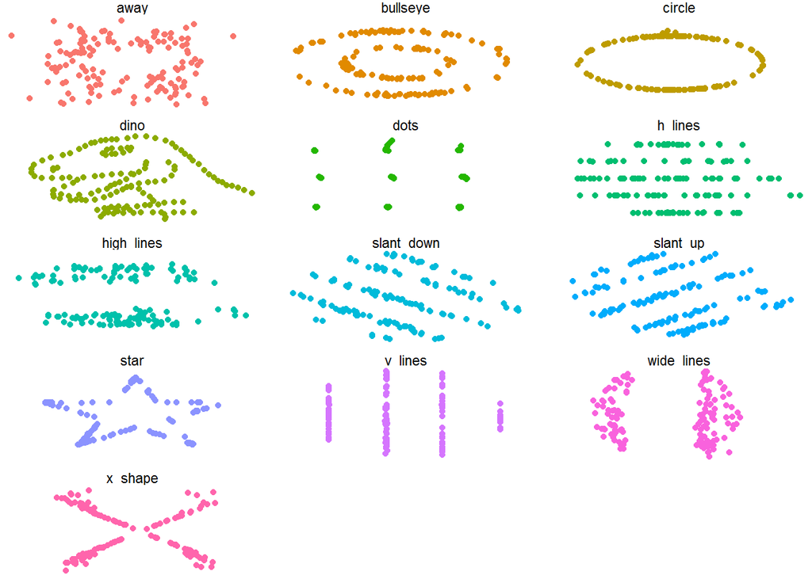

```r
ggplot(datasaurus_dozen, aes(x=x, y=y, color=dataset))+
    geom_point()+
    theme_void()+
    theme(legend.position = "none")+
    facet_wrap(~dataset, ncol=3);
```

### Animated graphics

- [Animated graphs](https://www.wjakethompson.com/post/datasaurus-dozen):

```r
library(magick);
```

```r
dataset=unique(datasaurus_dozen$dataset);
Img = image_graph(600, 400, res = 72); #open a new graphics device
for (i in 1:13)
{
  var=dataset[i];
  data=filter(datasaurus_dozen, dataset==var);
  p = ggplot(data, aes(x = x, y = y)) +
       geom_point(col="blue")+
    xlim(0,100)+ylim(0,100)+
    labs( x=paste("X Mean:", round(mean(data$x),digits=2),  "Y Mean:", round(mean(data$y),digits=2),  "X Sd:",round(sd(data$x),digits=2),  "Y Sd:", round(sd(data$y),digits=2),  "cor(X,Y):", round(cor(data$x,data$y),digits=2),sep=" ") );
  show(p);
}
dev.off();
```

```
## # A tibble: 13 x 7
##    format width height colorspace matte filesize density
##    <chr>  <int>  <int> <chr>      <lgl>    <int> <chr>
##  1 gif      600    400 sRGB       TRUE         0 72x72
##  2 gif      600    400 sRGB       TRUE         0 72x72
##  3 gif      600    400 sRGB       TRUE         0 72x72
##  4 gif      600    400 sRGB       TRUE         0 72x72
##  5 gif      600    400 sRGB       TRUE         0 72x72
##  6 gif      600    400 sRGB       TRUE         0 72x72
##  7 gif      600    400 sRGB       TRUE         0 72x72
##  8 gif      600    400 sRGB       TRUE         0 72x72
##  9 gif      600    400 sRGB       TRUE         0 72x72
## 10 gif      600    400 sRGB       TRUE         0 72x72
## 11 gif      600    400 sRGB       TRUE         0 72x72
## 12 gif      600    400 sRGB       TRUE         0 72x72
## 13 gif      600    400 sRGB       TRUE         0 72x72
```

[figure not shown]

```r
Img_Animation =image_animate(Img, fps = 5);
print(Img_Animation);
```

## Data Visualization of Accidental Drug Related Deaths

### Accidental Drug Related Deaths Data

- The second data set is [Accidental Drug Related Deaths 2012-2017](https://catalog.data.gov/dataset/accidental-drug-related-deaths-january-2012-sept-2015) data from https://www.data.gov/.
- The data can be read from the web directly:

```r
url="https://data.ct.gov/api/views/rybz-nyjw/rows.csv?accessType=DOWNLOAD";
Drug = read.csv(url, stringsAsFactors = FALSE);
```

- If you already downloaded the data, import from your local disk.

```r
Drug= read.csv("F:/DataCamp/data/Accidental_Drug_Related_Deaths__2012-June_2018.csv",header=TRUE, sep=",");
dim(Drug);
```

```
## [1] 4602   41
```

```r
str(Drug)
```

```
## 'data.frame':    4602 obs. of  41 variables:
##  $ ID                 : Factor w/ 4602 levels "12-0001","12-0002",..: 1 2 3 4 5 6 7 8 9 10 ...
##  $ Date               : Factor w/ 1929 levels "","01/01/2012 12:00:00 AM",..: 2 12 19 26 39 45 45 45 57 63 ...
##  $ DateType           : Factor w/ 3 levels "","DateofDeath",..: 2 2 2 2 2 2 2 2 2 2 ...
##  $ Age                : int  35 41 61 51 45 51 24 33 54 46 ...
##  $ Sex                : Factor w/ 4 levels "","Female","Male",..: 3 3 3 3 3 3 2 3 3 3 ...
##  $ Race               : Factor w/ 12 levels "","Asian Indian",..: 12 12 4 12 12 12 12 12 12 12 ...
##  $ ResidenceCity      : Factor w/ 353 levels "","ALFRED STATION",..: 120 31 63 285 116 314 280 35 67 273 ...
##  $ ResidenceCounty    : Factor w/ 73 levels "","AROOSTOOK",..: 63 25 19 19 25 44 19 70 39 25 ...
##  $ ResidenceState     : Factor w/ 23 levels "","AL","CA","CO",..: 1 1 1 1 1 1 1 1 1 1 ...
##  $ DeathCity          : Factor w/ 217 levels "","06340","AMSTON",..: 78 21 39 19 76 194 171 146 43 166 ...
##  $ DeathCounty        : Factor w/ 10 levels "","FAIRFIELD",..: 8 3 2 2 3 6 2 10 5 3 ...
##  $ Location           : Factor w/ 7 levels "","Convalescent Home",..: 7 4 4 6 7 7 4 4 7 4 ...
##  $ LocationifOther    : Factor w/ 323 levels "","\"Sober House\"",..: 1 1 1 188 1 109 1 1 1 1 ...
##  $ DescriptionofInjury: Factor w/ 306 levels "","Abuse","Abuse of Inhalants",..: 60 108 251 108 262 108 108 126 108 108 ...
```

[output cut: 27 more lines]